# Practical Machine Learning Assignment

April 10, 2016

# Basics

```r
# Set random seed
set.seed(1234)

# Clean cache; load libraries
rm(list = ls())
library(caret)
library(magrittr)
```

We now load the training data which are provided on the course webpage, at https://www.coursera.org/learn/practical-machine-learning/peer/R43St/prediction-assignment-writeup. Further background information on the data set is available at http://groupware.les.inf.puc-rio.br/har.

```r
# Load training data
dat <- read.table("pml-training.csv", header = TRUE, sep = ",")
```

The data set is fairly large, containing $19622$ observations on $160$ variables. It contains data on six persons (see variable “user_name”) who perform a weight lifting exercise in five different ways (variable “classe”). While classe = A corresponds to the correct way of doing the exercise, the other values of classe represent four common mistakes. The goal here is to predict the classe variable, using the predictor variables available in the sample.

# Data cleaning

As a first step, we conduct some basic checks on the data, which leads to the following data cleaning steps:

- For factor variables, replace the levels “#DIV/0!” and “” by NA entries
- Transfer some factor variables (containing many levels which appear to be numbers) to numeric
- Remove some variables which display no variation (after having performed the preceding two steps)
- Remove variables which contain NA values
- Remove the following variables, which are likely misleading: “X” (row index of the observations); “raw_timestamp_part_1” and “raw_timestamp_part_1” (integer-valued time codes)

These initial screening steps reduce the number of variables to $57$, down from $160$.

# Split data into training/validation sample

According to the lecture on prediction study design, it is reasonable to choose a 3:1 relationship between the number of observations used for training versus validation. Note that we already have a test sample (provided as a separate data file).

```r
inTraining <- createDataPartition(dat$classe, p = 0.75, list = FALSE)
traindat <- dat[inTraining, ]
valdat <- dat[-inTraining, ]
```

# Approach for prediction: Overview

Our approach follows two steps: In step A, we use the training sample to fit two methods. In step B, we use the validation sample to analyze the performance of various convex combinations between the two methods (with combination weight $\omega$ on the first method, and weight $1-\omega$ on the second method). We then use the value $\omega^* \in [0, 1]$ for which the validation sample accuracy of the combined forecast is maxized. Note that step B is motivated by research findings that combining predictors is often more successful than using a single method (see the notes to week four of the lecture).

We next describe the two steps in more detail.

## Step A

We first fit the following two models to the training data:

- “pda”, based on all $57$ variables
- “treebag”, based on the ten most important variables identified by “pda”

Both models are part of the caret package, and can be fit to the present data set within a few minutes on a standard notebook. In the case of “treebagg”, we use a reduced set of important predictor variables in order to reduce the computational effort. We also experimented with other models implemented in the caret package (such as “gbm” or “rf”); however, these appear to be computationally very challenging for the present data set.

In order to fit “pda” and “treebag”, we use caret’s default setup for *trainControl*. Note that “pda” involves a single tuning parameter, $\lambda$, which governs the degree of regularization (see https://cran.r-project.org/web/packages/mda/mda.pdf for details). “treebag” does not involve any tuning parameters.

```r
# Fit penalized discriminant analysis
fit1 <- train(classe~., method = "pda", data = traindat)
# Find ten most important variables, according to pda
topTen <- varImp(fit1)$importance %>% (function(z) rowMeans(as.matrix(z))) %>%
  (function(z) sort(z, decreasing = TRUE)) %>% (function(z) head(z, 10))

# Create small version of training data, containing only
# ten most important variables
traindat_small <- traindat[, c(names(topTen), "classe")]

# Fit bagged tree
fit2 <- train(classe~., method = "treebag", data = traindat_small)
```

## Step B

In order to combine the predictions of the two models, we compute the weighted average of the two models’ class probabilities, and then select the class with the highest combined probability. To describe this more formally, let $p_{i,c}^{pda}$ denote pda’s predicted probability for case $i$ and class $c$, and let $p_{i,c}^{tba}$ denote treebag’s predicted probability for case $i$ and class $c$. The combined probability using weight $\omega$ is given by $p_{i,c}^{comb}(\omega) = \omega~p_{i,c}^{pda} + (1-\omega)~p_{i,c}^{tba}$. Our classification is then given by the class $c$ for which $p_{i,c}^{comb}(\omega)$ is maximized.

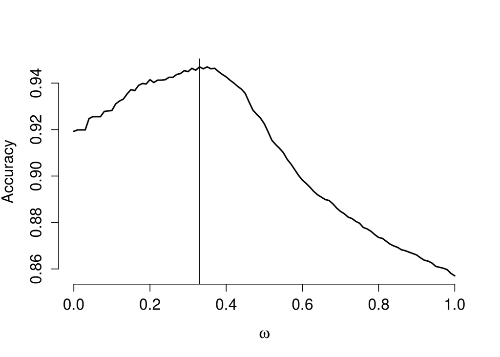

```r
# Compute validation sample probabilities for both models
pred1 <- predict(fit1, newdata = valdat, type = "prob")
pred2 <- predict(fit2, newdata = valdat, type = "prob")

# Make grid of combination weights
omega <- seq(from = 0, to = 1, by = 0.01)

# Compute accuracy for each choice of omega
acc_omega <- rep(0, length(omega))

# Helper function needed below
helper_fun <- function(z) c("A", "B", "C", "D", "E")[which.max(z)]

# Loop over omega
for (ii in 1:length(omega)){
  # Combined probabilities
  pred_c <- omega[ii]*pred1 + (1-omega[ii])*pred2
  # Classification
  class_c <- apply(pred_c, 1, helper_fun)
  # Accuracy
  acc_omega[ii] <- mean(class_c == valdat$classe)
}

# Best choice of omega
omega_opt <- omega[which.max(acc_omega)]

# Plot
plot(x = omega, y = acc_omega, xlab = expression(omega), ylab = "Accuracy",
     bty = "n", type = "l", lwd = 2, cex.axis = 1.3, cex.lab = 1.3)
abline(v = omega_opt)
```

```r
# Confusion matrix for best choice of omega
pred_opt <- omega_opt*pred1 + (1-omega_opt)*pred2
class_opt <- apply(pred_opt, 1, helper_fun)
confusionMatrix(class_opt, valdat$classe)
```

```
## Confusion Matrix and Statistics
##
##           Reference
## Prediction    A    B    C    D    E
##          A 1357   66   11    3    5
##          B   18  844   22    2    3
##          C   13   36  817   50    4
##          D    7    2    5  745    8
##          E    0    1    0    4  881
##
## Overall Statistics
##
##                Accuracy : 0.947
##                  95% CI : (0.9403, 0.9531)
##     No Information Rate : 0.2845
##     P-Value [Acc > NIR] : < 2.2e-16
##
##                   Kappa : 0.9329
##  Mcnemar's Test P-Value : 3.617e-13
##
## Statistics by Class:
##
##                      Class: A Class: B Class: C Class: D Class: E
## Sensitivity            0.9728   0.8894   0.9556   0.9266   0.9778
## Specificity            0.9758   0.9886   0.9746   0.9946   0.9988
## Pos Pred Value         0.9411   0.9494   0.8880   0.9713   0.9944
## Neg Pred Value         0.9890   0.9738   0.9905   0.9857   0.9950
## Prevalence             0.2845   0.1935   0.1743   0.1639   0.1837
## Detection Rate         0.2767   0.1721   0.1666   0.1519   0.1796
## Detection Prevalence   0.2940   0.1813   0.1876   0.1564   0.1807
## Balanced Accuracy      0.9743   0.9390   0.9651   0.9606   0.9883
```

# Test sample predictions

```r
# Load data
testdat <- read.table("pml-testing.csv", sep = ",", header = TRUE)

# Compute two model predictions
pred1_test <- predict(fit1, newdata = testdat, type = "prob")
pred2_test <- predict(fit2, newdata = testdat, type = "prob")

# Compute combined prediction
pred_opt_test <- pred1_test * omega_opt + pred2_test * (1-omega_opt)
class_opt_test <- apply(pred_opt_test, 1, helper_fun)
```